# Estimating AONR and EONR with R: A tutorial and case study

# Preliminaries

First we need to load a few packages

```r
library(ggplot2)
library(nlraa)
library(car)
library(mgcv)
library(magrittr)
## Load function to compute the EONR
source("eonr.R")
```

# Introduction

This tutorial and case study are intended to illustrate the process of estimating AONR and EONR with a real dataset. The data here were obtained from Table 1 from a publication by Francis et al. (2021). When estimating the EONR it is important that the units for fertilizer and yield match. For that reason, we use $kg \; ha^{-1}$ for yield and for the fertilizer.

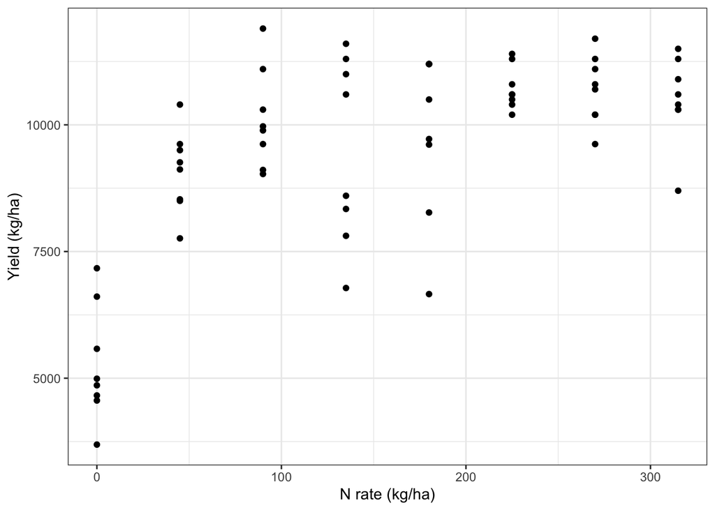

```r
red <- read.csv("red_clover.csv")
## Create column with yield in kg/ha
red$Yield_kgha <- red$Yield * 1e3
## Visualize the data
ggplot(data = red, aes(x = Nrate, y = Yield_kgha)) +
  geom_point() +
  ylab("Yield (kg/ha)") +
  xlab("N rate (kg/ha)") +
  theme_bw()
```

# Simple Analysis

The first approach will be to fit the linear-plateau and quadratic-plateau (with 3 parameters) models and assess the impact of the uncertainty in the model choice. In terms for model fit, both models have identical AIC values and number of parameters. The R-squared is not computed or included here but it would be identical.

```r
fm.QP <- nls(Yield_kgha ~ SSquadp3xs(Nrate, a, b, xs), data = red)
fm.LP <- nls(Yield_kgha ~ SSlinp(Nrate, a, b, xs), data = red)

(ictab <- IC_tab(fm.QP, fm.LP)) ## Identical fit
```

|  | model | df | AIC | AICc | BIC | dAIC | weight |
| --- | --- | --- | --- | --- | --- | --- | --- |
| 1 | fm.QP | 4 | 1089.936 | 1090.614 | 1098.572 | 0.000000e+00 | 0.5 |
| 2 | fm.LP | 4 | 1089.936 | 1090.614 | 1098.572 | 5.911716e-12 | 0.5 |

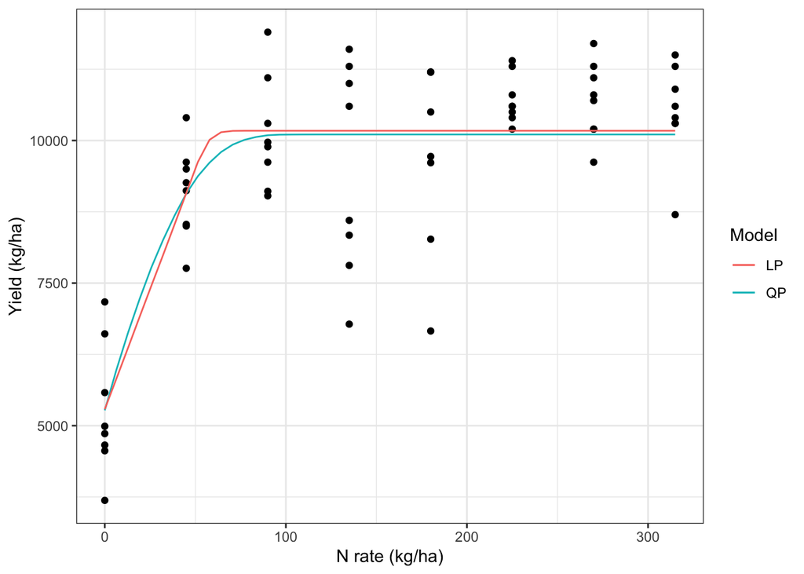

```r
ndat <- data.frame(Nrate = seq(min(red$Nrate), max(red$Nrate), length.out = 50))
prds.QP <- predict_nls(fm.QP, newdata = ndat, interval = "conf")
ndatA.QP <- cbind(ndat, prds.QP)

prds.LP <- predict_nls(fm.LP, newdata = ndat, interval = "conf")
ndatA.LP <- cbind(ndat, prds.LP)

ggplot() +
  geom_point(data = red, aes(x = Nrate, y = Yield_kgha)) +
  geom_line(data = ndatA.QP, aes(Nrate, Estimate, color = "QP")) +
  geom_line(data = ndatA.LP, aes(Nrate, Estimate, color = "LP")) +
  ylab("Yield (kg/ha)") +
  xlab("N rate (kg/ha)") +
  guides(color = guide_legend(title = "Model")) +
  theme_bw()
```

## Computing AONR and EONR

Given that both models have identical fit, AIC and R-squares it is reasonable to instead apply model averaging to resolve this conflict. The AONR estimate for each model is simply the break-point, which is a parameter from the model. For LP it is 58 and for QP it is 86 . In order to compute the confidence intervals we could use the profile method or bootstrap. We choose the bootstrap method as it will be more generally applicable to other model fits later.

```r
## Extract AONR for both models
AONR.LP <- round(coef(fm.LP)[3])
AONR.QP <- round(coef(fm.QP)[3])
### Confidence intervals for AONR estimates ###
fm.QP.bt <- boot_nls(fm.QP, R = 5e3, cores = 4)
```

```
## Number of times model fit did not converge 1266 out of 5000
```

```r
fm.LP.bt <- boot_nls(fm.LP, R = 5e3, cores = 4)
```

```
## Number of times model fit did not converge 901 out of 5000
```

```r
AONR.QP.ci <- confint(fm.QP.bt)
AONR.LP.ci <- confint(fm.LP.bt)
## Model averaging
prds.avg <- predict_nls(fm.LP, fm.QP, newdata = ndat, interval = "conf")
ndatA.avg <- cbind(ndat, prds.avg)

AONR.avg <- round(ictab$weight %*% c(coef(fm.QP)[3], coef(fm.LP)[3]))

prds.avg <- predict_nls(fm.LP, fm.QP, newdata = ndat, interval = "conf")
ndatA.avg <- cbind(ndat, prds.avg)

AONR.avg.ci <- confint(c(fm.QP.bt, fm.LP.bt))
```

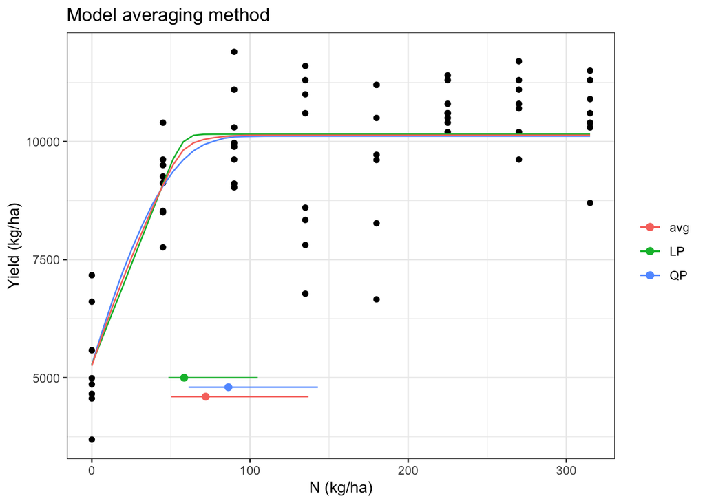

```r
ggplot() +
  geom_point(data = red, aes(x = Nrate, y = Yield_kgha)) +
  geom_line(data = ndatA.QP, aes(Nrate, Estimate, color = "QP")) +
  geom_line(data = ndatA.LP, aes(Nrate, Estimate, color = "LP")) +
  geom_line(data = ndatA.avg, aes(Nrate, Estimate, color = "avg")) +
  geom_point(aes(x = coef(fm.LP)[3], y = 5000, color = "LP"), size = 2) +
  geom_errorbarh(aes(xmin = AONR.LP.ci[3,1], xmax = AONR.LP.ci[3,2], y = 5000, color = "LP")) +
  geom_point(aes(x = coef(fm.QP)[3], y = 4800, color = "QP"), size = 2) +
  geom_errorbarh(aes(xmin = AONR.QP.ci[3,1], xmax = AONR.QP.ci[3,2], y = 4800, color = "QP")) +
  geom_point(aes(x = AONR.avg, y = 4600, color = "avg"), size = 2) +
  geom_errorbarh(aes(xmin = AONR.avg.ci[3,1], xmax = AONR.avg.ci[3,2], y = 4600, color = "avg")) +
  guides(color = guide_legend(title = element_blank())) +
  theme_bw() + xlab("N (kg/ha)") + ylab("Yield (kg/ha)") +
  ggtitle("Model averaging method")
```

Even though the differences are small, using model averaging better accounts for the uncertainty in the choice between the LP and QP models. Similarly, by using bootstrap we can combine the uncertainty in the bootstrap samples from the two models and compute the 95% confidence interval for the AONR for the average model.

```r
aonrs <- data.frame(model = c("LP", "QP", "avg"),
                  AONR = c(AONR.LP, AONR.QP, AONR.avg),
                  lower = round(c(AONR.LP.ci[3, 1], AONR.QP.ci[3, 1], AONR.avg.ci[3, 1])),
                  upper = round(c(AONR.LP.ci[3, 2], AONR.QP.ci[3, 2], AONR.avg.ci[3, 2])))
knitr::kable(aonrs, caption = "AONR and confidece intervals for LP, QP and average method") %>%
  kableExtra::kable_styling(full_width = FALSE)
```

AONR and confidece intervals for LP, QP and average method

| model | AONR | lower | upper |
| --- | --- | --- | --- |
| LP | 58 | 49 | 105 |
| QP | 86 | 61 | 143 |
| avg | 72 | 50 | 137 |

We need to be careful when computing the EONR. First, we need a fertilizer to grain price ration and we use a value of 5.6 in this case. For the LP model, the EONR is determined by the slope and when this slope is greater than the fertilizer to grain price ratio, then the EONR is equivalent to the AONR. For the QP model, the EONR will be somewhat lower than the AONR. For this we can use the **eonr** function which we sourced at the beginning of this tutorial (this function is available in github: https://github.com/femiguez/optimum_fertilizer).

```r
EONR.LP <- coef(fm.LP)[3] ## LP EONR
EONR.QP <- eonr(fm.QP, max.rate = coef(fm.QP)[3]) ## QP EONR
## Taking the mean in this case is sensible because the AIC weights
## for both models were identical. Otherwise, consider using AIC weights
EONR.avg <- mean(c(EONR.LP, EONR.QP))
eonrs <- data.frame(model = c("LP", "QP", "avg"),
                  EONR = round(c(EONR.LP, EONR.QP, EONR.avg)))
knitr::kable(eonrs, caption = "EONR for LP, QP and average method") %>%
  kableExtra::kable_styling(full_width = FALSE)
```

EONR for LP, QP and average method

| model | EONR |
| --- | --- |
| LP | 58 |
| QP | 82 |
| avg | 70 |

## What about GAMS?

Generalized Additive Models are gaining traction in the analysis of agronomic data. They are one of the best options for certain types of data. However, when used for estimating the AONR (or EONR) they can be fairly unstable as the typical sample size is not sufficiently large. Having less than 15-20 N rates means that the fit will vary substantially depending on the dimension of the basis used. This is illustrated below. Different values of $k$ result in fairly different fits and therefore in different estimates for the EONR. We do not estimate the AONR as it is not defined for GAM models given that the function does not necessarily reach a plateau.

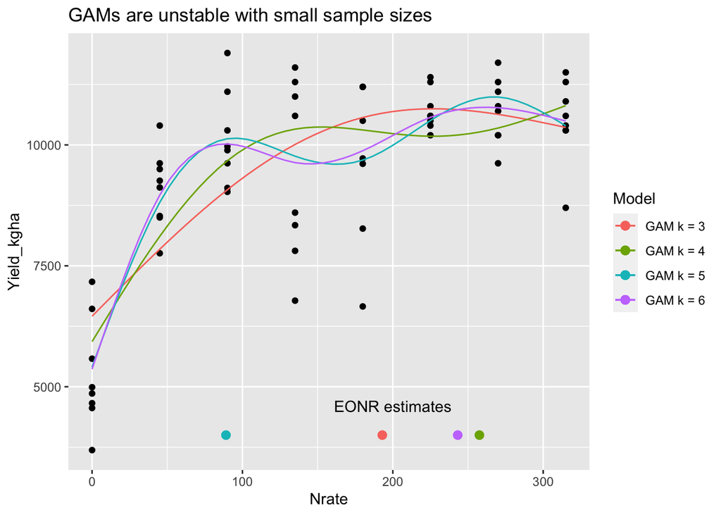

```r
fm.G3.kgha <- gam(Yield_kgha ~ s(Nrate, k = 3), data = red)
fm.G4.kgha <- gam(Yield_kgha ~ s(Nrate, k = 4), data = red)
fm.G5.kgha <- gam(Yield_kgha ~ s(Nrate, k = 5), data = red)
fm.G6.kgha <- gam(Yield_kgha ~ s(Nrate, k = 6), data = red)

eonr.G3 <- eonr(fm.G3.kgha)
eonr.G4 <- eonr(fm.G4.kgha)
eonr.G5 <- eonr(fm.G5.kgha)
eonr.G6 <- eonr(fm.G6.kgha)

prds.G3 <- predict_gam(fm.G3.kgha, newdata = ndat, interval = "conf")
ndatA.G3 <- cbind(ndat, prds.G3)

prds.G4 <- predict_gam(fm.G4.kgha, newdata = ndat, interval = "conf")
ndatA.G4 <- cbind(ndat, prds.G4)

prds.G5 <- predict_gam(fm.G5.kgha, newdata = ndat, interval = "conf")
ndatA.G5 <- cbind(ndat, prds.G5)

prds.G6 <- predict_gam(fm.G6.kgha, newdata = ndat, interval = "conf")
ndatA.G6 <- cbind(ndat, prds.G6)

ggplot() +
  geom_point(data = red, aes(x = Nrate, y = Yield_kgha)) +
  geom_line(data = ndatA.G3, aes(Nrate, Estimate, color = "GAM k = 3")) +
  geom_line(data = ndatA.G4, aes(Nrate, Estimate, color = "GAM k = 4")) +
  geom_line(data = ndatA.G5, aes(Nrate, Estimate, color = "GAM k = 5")) +
  geom_line(data = ndatA.G6, aes(Nrate, Estimate, color = "GAM k = 6")) +
  geom_point(aes(x = eonr.G3, y = 4000, color = "GAM k = 3"), size = 2.5) +
  geom_point(aes(x = eonr.G4, y = 4000, color = "GAM k = 4"), size = 2.5) +
  geom_point(aes(x = eonr.G5, y = 4000, color = "GAM k = 5"), size = 2.5) +
  geom_point(aes(x = eonr.G6, y = 4000, color = "GAM k = 6"), size = 2.5) +
  geom_text(aes(x = 200, y = 4600, label = "EONR estimates")) +
  guides(color = guide_legend(title = "Model")) +
  ggtitle("GAMs are unstable with small sample sizes")
```

The estimates for the EONR for these different model choices are:

```r
gam.eonrs <- data.frame(model = c("k = 3", "k = 4", "k = 5", "k = 6"),
                  EONR = round(c(eonr.G3, eonr.G4, eonr.G5, eonr.G6)))
knitr::kable(gam.eonrs, caption = "EONR for different GAMS") %>%
  kableExtra::kable_styling(full_width = FALSE)
```

EONR for different GAMS

| model | EONR |
| --- | --- |
| k = 3 | 193 |
| k = 4 | 258 |
| k = 5 | 89 |
| k = 6 | 243 |

## Additional Details

More details about this analysis can be found at: https://github.com/femiguez/optimum_fertilizer.